# diagnostic graphics

## Packages

```r
library(tidyverse)
theme_set(theme_bw())
library(car)
library(broom)
library(broom.mixed)
library(magrittr)
## modeling
library(lme4)
library(MCMCglmm)
library(glmmTMB)
library(coda) ## Bayesian methods (trace plots etc.)
library(lattice) ## built-in
library(cowplot)
library(nullabor) ## visual inference
```

## Diagnostics: goals and ideas

- detect model failure
- display badness of fit
- fast/convenient
- residuals emphasize deviation, hide fitted pattern

## Diagnostics: principles

- diagnosis is exploration
- avoid making decisions based on p-values
- judge by eye (?¿?¿?¿?¿)
- **not** "are my data (linear|normal|heteroscedastic)?";  
  rather, *"how much do the violations change my conclusions?"*

## diagnostics *after* fitting model

- Interested in *conditional*, not *marginal* values
- What does this mean?

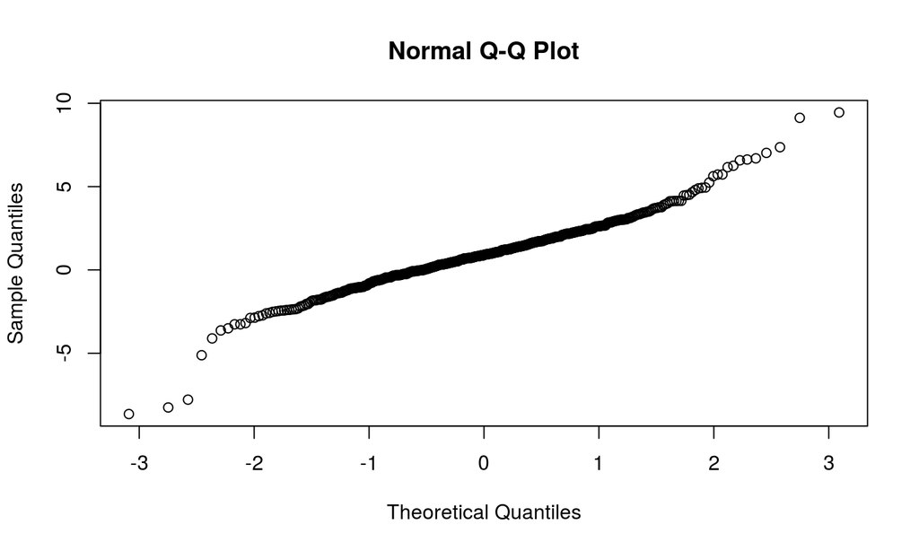

## marginal distributions

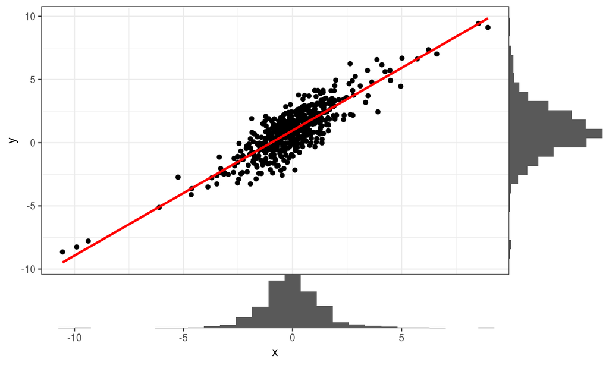

## quantile plots

```r
m0 <- lm(y~x,dd)
a0 <- (augment(m0)
  %>% select(x,y,.resid)
  %>% gather(type,value)
  %>% mutate(type=factor(type,levels=c("x","y",".resid")))
)
```

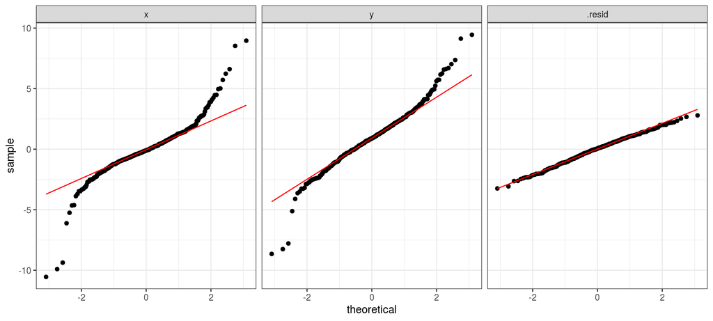

```r
(ggplot(a0,aes(sample=value))
  + stat_qq()
  + facet_wrap(~type)
  + stat_qq_line(colour="red")
)
```

## model diagnosis

look for *mis-specification* (in order!):

- mean model (bias)
- variance model (heteroscedasticity)
- distributional model (e.g. non-normality)

influential points/groups (leverage/outliers/etc.)

upstream problems affect downstream diagnostics

## bias

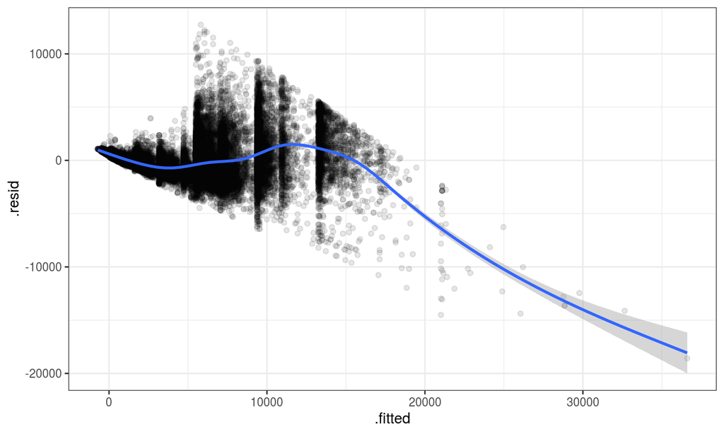

```r
m1 <- lm(price~carat,diamonds)
a1 <- augment(m1,data=diamonds) ## include original data
ggplot(a1,aes(.fitted,.resid)) +
    geom_point(alpha=0.1)+geom_smooth()
```

## bias 2: faceting/colouring

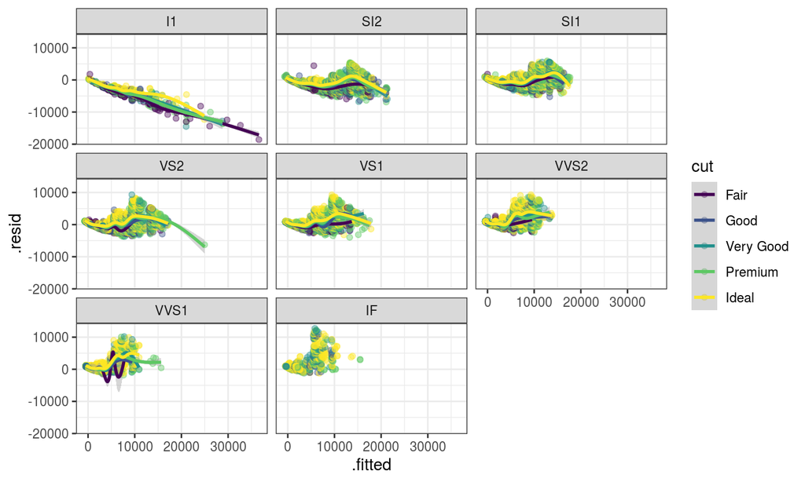

```r
ggplot(a1,aes(.fitted,.resid,colour=cut)) +
    facet_wrap(~clarity) +
    geom_point(alpha=0.4)+geom_smooth()
```

useful to use dynamic graphics `ggmap::gglocator` (may need `devtools::install_github("dkahle/ggmap")`)

## solutions to bias

- fix the model
- add covariates and interactions
- transform predictors and/or responses (`acepack::avas`, Tibshirani (1987))
- nonlinear terms
  - polynomials
  - splines (regular or penalized)
  - 'real' nonlinearity

## heteroscedasticity diagnostics

- scale-location plot
- use \(\sqrt{|r_i|}\):
  - absolute value shows trend
  - square root decreases skewness
- use standardized residuals  
  (adjust variance for position)

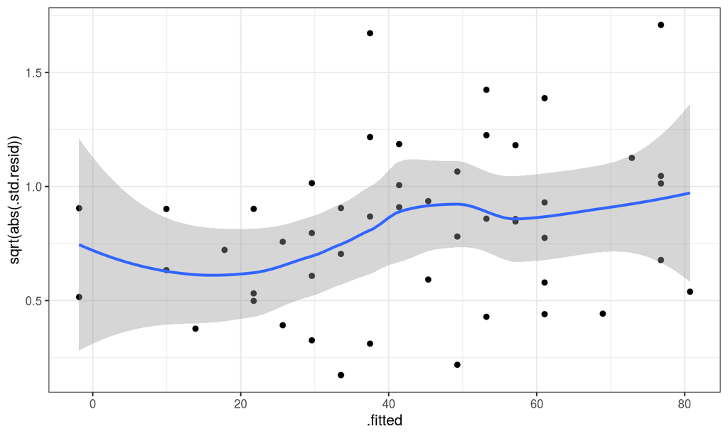

```r
m2 <- lm(dist ~ speed, data=cars)
ggplot(augment(m2),aes(.fitted,sqrt(abs(.std.resid))))+
    geom_point()+geom_smooth()
```

## heteroscedasticity solutions

- transformation (Tibshirani 1987)
- explicitly model heteroscedasticity  
  e.g. generalized least squares, GLMs
- robust variance-covariance estimation  
  (e.g. `sandwich` package: Zeileis (2006))

## distributional assumptions

- least important
- quantile-quantile plots

## histograms

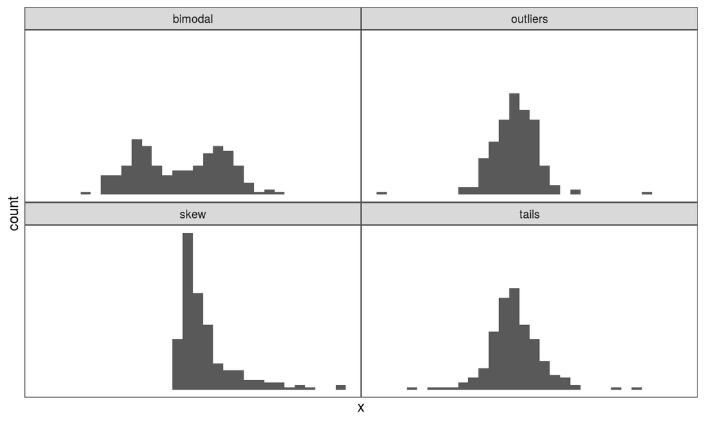

## quantile plots

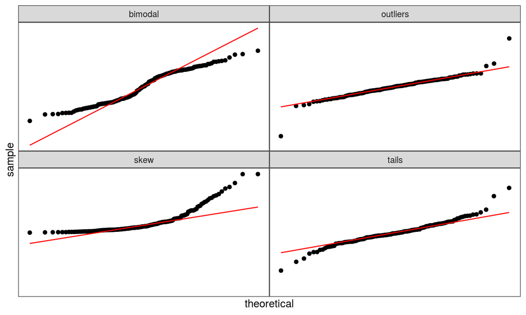

## distributional solutions

- transformation (`avas`, Box-Cox (`MASS:boxcox`), Yeo-Johnson etc. [`?car::bcPower`])
- GLMs
- maximum likelihood estimation

## correlation

rarely tested! can't detect without some kind of structure in data

- autocorrelation plots from residuals
- grouped autocorrelation: use `gls()` on residuals
- spatial autocorrelation: semivariance plot
- or look at maps of residuals with `size=abs(.resid)`, `colour=sign(.resid)` (or colour ramp)

## binary data

- residuals for count data only \(\approx\) Normal for large counts
- add smooths or average of grouped data

Fit:

```r
library(lme4)
data(Contraception,package="mlmRev")
Contraception <- Contraception %>%
    mutate(ch=factor(livch != 0, labels = c("N", "Y")))
m3 <- glmer(use ~ age * ch + I(age^2) + urban + (1 | urban:district),
            data=Contraception, family=binomial)
```

## plot

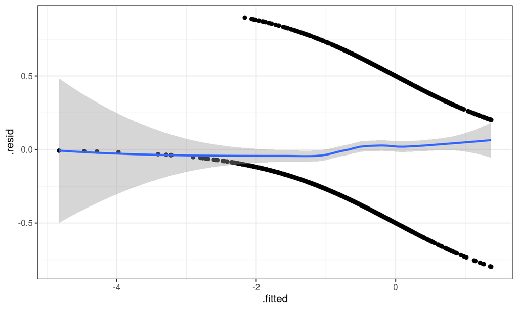

```r
a3 <- augment(m3,data=Contraception,type.residuals="response")
gg_bin1 <- (ggplot(a3,aes(.fitted,.resid))+
            geom_point()+ geom_smooth(method="loess"))
print(gg_bin1)
```

## grouping

```r
get_mid <- function(x) {
    cc <- as.character(x)
    lo <- as.numeric(gsub("[\\(\\[]([[:digit:].-]+).*","\\1",cc))
    hi <- as.numeric(gsub(".*,([[:digit:].-]+)[])]","\\1",cc))
    return((lo+hi)/2)
}
(a3
    %>% mutate(.fit_cut=cut_number(.fitted,20))
    %>% group_by(.fit_cut)
    %>% summarise(.resid=mean(.resid))
    %>% ungroup
    %>% mutate(.fitted=get_mid(.fit_cut))
) -> a3_sum
```

## plot with grouping

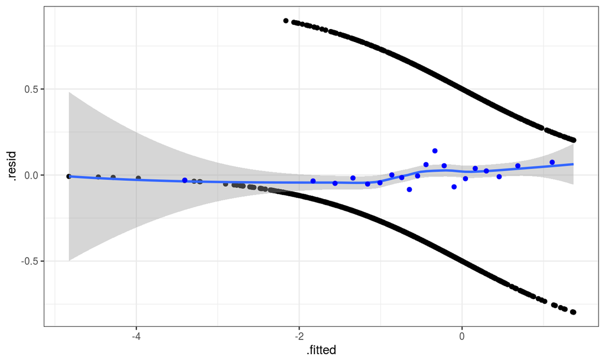

```r
gg_bin1+geom_point(data=a3_sum,colour="blue")
```

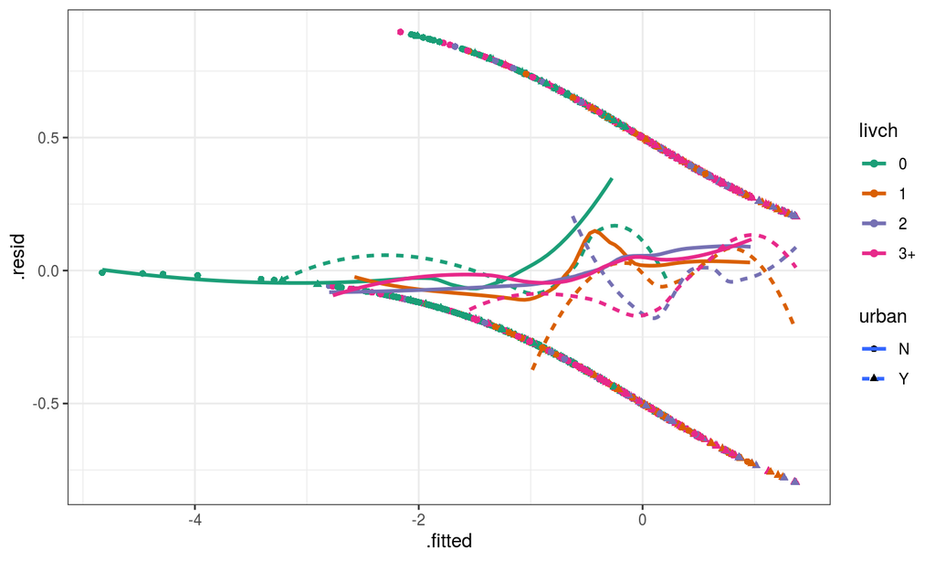

```r
ggplot(a3,aes(.fitted,.resid,colour=livch,shape=urban,linetype=urban))+
            geom_point()+ geom_smooth(se=FALSE)+
    scale_colour_brewer(palette="Dark2")
```

## keep trying …

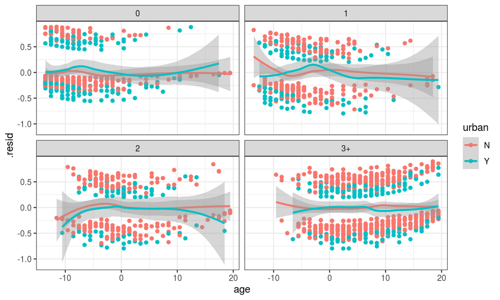

```r
ggplot(a3,aes(age,.resid,colour=urban))+
    geom_point()+
    geom_smooth(method="loess")+
    facet_wrap(~livch)
```

- loess too bumpy?

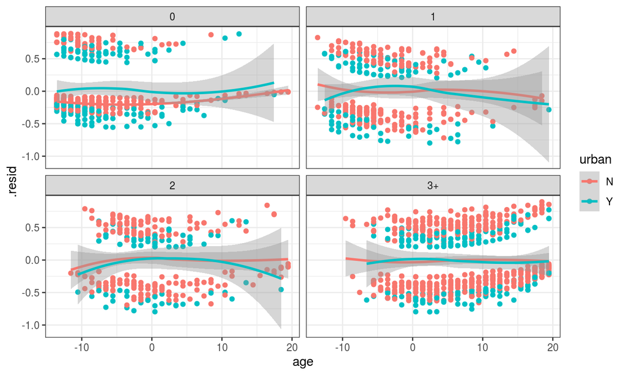

```r
ggplot(a3,aes(age,.resid,colour=urban))+
    geom_point()+
    geom_smooth(method="loess",
                method.args=list(family="symmetric"),span=1)+
    facet_wrap(~livch)
```

- try `method="gam"` ?

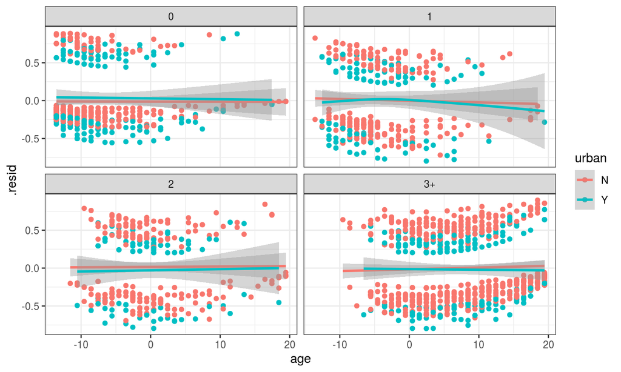

```r
ggplot(a3,aes(age,.resid,colour=urban))+
    geom_point()+
    geom_smooth(method="gam",formula =y ~ s(x, k=25)) +
    facet_wrap(~livch)
```

- note: `qq.gam()` (Augustin, Sauleau, and Wood 2012)
- improved QQ for GLMs (only for fits via `mgcv::gam()` ?)
- binary data still problematic: from `?qq.gam`,

> Note that plots for raw residuals from fits to binary data contain almost no useful information about model fit. Whether the residual is negative or positive is decided by whether the response is zero or one. The magnitude of the residual, given its sign, is determined entirely by the fitted values. In consequence only the most gross violations of the model are detectable from QQ-plots of residuals for binary data. To really check distributional assumptions from residuals for binary data you have to be able to group the data somehow. Binomial models other than binary are ok.

## coverage

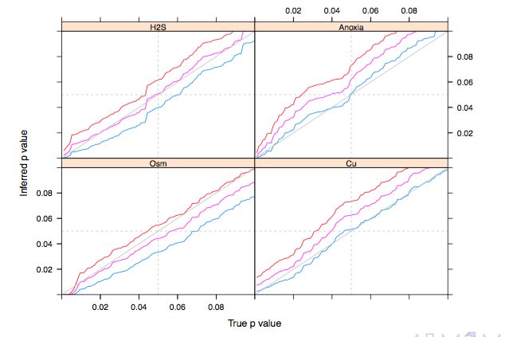

## likelihood profiles

use \(\sqrt{-2 \log (L-L_0)}\) (\(\sf V\)-shaped), signed square root (straight line/symmetry)

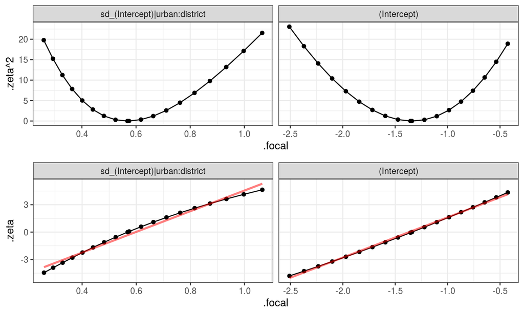

## MCMC

- trace plots - should look like white noise, with no trend …

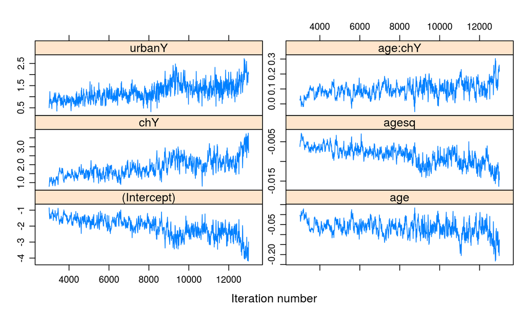

```r
lattice::xyplot(m4$Sol,aspect="fill",layout=c(2,3))
```

- trace plots

## posterior predictive plots

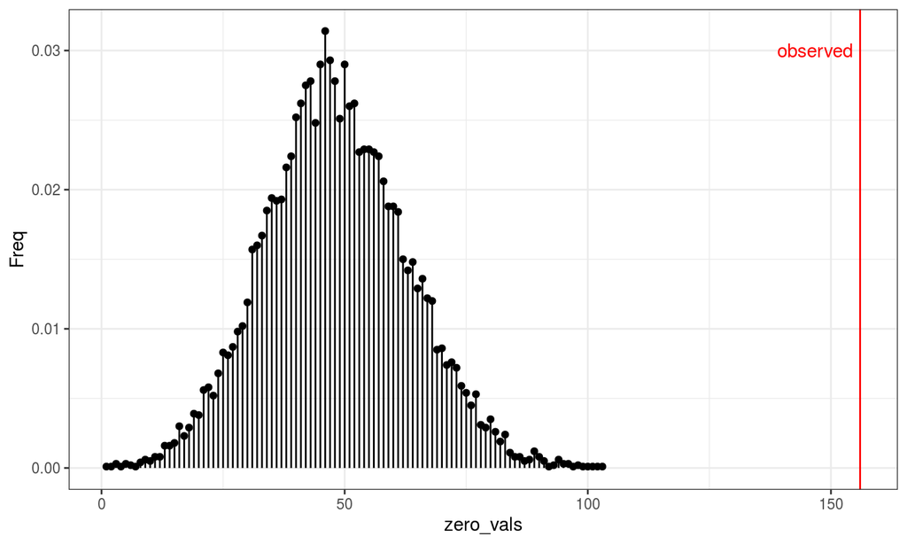

```r
set.seed(101); nsim <- 1e4
owls_sim <- simulate(owls_nb1,nsim)
sumfun <- function(x)sum(x==0)
zero_vals <- apply(owls_sim,2,sumfun)
dz <- as.data.frame(table(zero_vals)/nsim) %>%
    mutate(zero_vals=as.numeric(zero_vals))
obsval <- sumfun(Owls$SiblingNegotiation)
gsim <- ggplot(dz,aes(zero_vals,Freq))+geom_point()+
    geom_segment(aes(xend=zero_vals,yend=0))+
    geom_vline(xintercept=obsval,col="red")+
    annotate(geom="text",x=obsval,y=0.03,label="observed",
             col="red",hjust=1.1)
```

## complex models (Wickham et al. 2010; Gelman 2004; A. Buja et al. 2009)

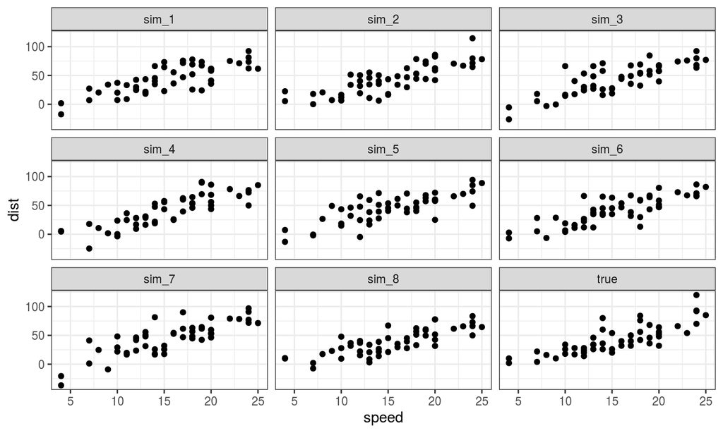

```r
simdat <- (simulate(m2,8)
    %>% data.frame(speed=cars$speed)
    %>% gather(sample,dist,-speed))
ddsim <- (cars
    %>% select(dist,speed)
    %>% mutate(sample="true")
    %>% bind_rows(simdat))
ddsimplot <- ggplot(ddsim,aes(speed,dist))+geom_point()+
    facet_wrap(~sample)
```

## references

Augustin, Nicole H., Erik-André Sauleau, and Simon N. Wood. 2012. “On Quantile Quantile Plots for Generalized Linear Models.” *Computational Statistics & Data Analysis* 56 (8): 2404–9. doi:10.1016/j.csda.2012.01.026.

Buja, A., D. Cook, H. Hofmann, M. Lawrence, E.-K. Lee, D. F. Swayne, and H. Wickham. 2009. “Statistical Inference for Exploratory Data Analysis and Model Diagnostics.” *Philosophical Transactions of the Royal Society A: Mathematical, Physical and Engineering Sciences* 367 (1906): 4361–83. doi:10.1098/rsta.2009.0120.

Gelman, Andrew. 2004. “Exploratory Data Analysis for Complex Models.” *Journal of Computational and Graphical Statistics* 13 (4): 755–79. doi:10.1198/106186004X11435.

Quinn, Gerry P., and Michael J. Keough. 2002. *Experimental Design and Data Analysis for Biologists*. Cambridge, England: Cambridge University Press.

Tibshirani, Rob. 1987. “Estimating Optimal Transformations for Regression.” *Journal of the American Statistical Association* 83: 394.

Wickham, H., D. Cook, H. Hofmann, and Andreas Buja. 2010. “Graphical Inference for Infovis.” *IEEE Transactions on Visualization and Computer Graphics* 16 (6): 973–79. doi:10.1109/TVCG.2010.161.

Zeileis, Achim. 2006. “Object-Oriented Computation of Sandwich Estimators.” *Journal of Statistical Software* 16 (9): 1–16. http://www.jstatsoft.org/v16/i09/.